# Loan Worthiness of a Borrower - Data Modeling using Python

## Project Goal:

To create a model that will help predict if the borrower has a high probability of paying their loan back in full.

## Dataset:

In this project, we are using publicly available dataset from Lendingclub.com from 2007 - 2010 to predict if the boorower paid back their entire loan amount to the investor.

The data set contains the following features:

# Let us start with importing the required Libraries

```python
import numpy as np
import pandas as pd

import matplotlib.pyplot as plt
import seaborn as sns
%matplotlib inline
sns.set_style('whitegrid')
plt.rcParams["patch.force_edgecolor"] = True
```

## Call the Dataset

```python
loanworth = pd.read_csv('loan.csv')
```

**Check out the info(), head(), and describe() methods on loanworth.**

```python
loanworth.info()
```

```
<class 'pandas.core.frame.DataFrame'>
RangeIndex: 9578 entries, 0 to 9577
Data columns (total 14 columns):
credit.policy        9578 non-null int64
purpose              9578 non-null object
int.rate             9578 non-null float64
installment          9578 non-null float64
log.annual.inc       9578 non-null float64
dti                  9578 non-null float64
fico                 9578 non-null int64
days.with.cr.line    9578 non-null float64
revol.bal            9578 non-null int64
revol.util           9578 non-null float64
inq.last.6mths       9578 non-null int64
delinq.2yrs          9578 non-null int64
pub.rec              9578 non-null int64
not.fully.paid       9578 non-null int64
dtypes: float64(6), int64(7), object(1)
memory usage: 1.0+ MB
```

```python
loanworth.describe()
```

|  | credit.policy | int.rate | installment | log.annual.inc | dti | fico | days.with.cr.line | revol.bal | revol.util | inq.last.6mths | delinq.2yrs | pub.rec | not.fully.paid |
| --- | --- | --- | --- | --- | --- | --- | --- | --- | --- | --- | --- | --- | --- |
| count | 9578.000000 | 9578.000000 | 9578.000000 | 9578.000000 | 9578.000000 | 9578.000000 | 9578.000000 | 9.578000e+03 | 9578.000000 | 9578.000000 | 9578.000000 | 9578.000000 | 9578.000000 |
| mean | 0.804970 | 0.122640 | 319.089413 | 10.932117 | 12.606679 | 710.846314 | 4560.767197 | 1.691396e+04 | 46.799236 | 1.577469 | 0.163708 | 0.062122 | 0.160054 |
| std | 0.396245 | 0.026847 | 207.071301 | 0.614813 | 6.883970 | 37.970537 | 2496.930377 | 3.375619e+04 | 29.014417 | 2.200245 | 0.546215 | 0.262126 | 0.366676 |
| min | 0.000000 | 0.060000 | 15.670000 | 7.547502 | 0.000000 | 612.000000 | 178.958333 | 0.000000e+00 | 0.000000 | 0.000000 | 0.000000 | 0.000000 | 0.000000 |
| 25% | 1.000000 | 0.103900 | 163.770000 | 10.558414 | 7.212500 | 682.000000 | 2820.000000 | 3.187000e+03 | 22.600000 | 0.000000 | 0.000000 | 0.000000 | 0.000000 |
| 50% | 1.000000 | 0.122100 | 268.950000 | 10.928884 | 12.665000 | 707.000000 | 4139.958333 | 8.596000e+03 | 46.300000 | 1.000000 | 0.000000 | 0.000000 | 0.000000 |
| 75% | 1.000000 | 0.140700 | 432.762500 | 11.291293 | 17.950000 | 737.000000 | 5730.000000 | 1.824950e+04 | 70.900000 | 2.000000 | 0.000000 | 0.000000 | 0.000000 |
| max | 1.000000 | 0.216400 | 940.140000 | 14.528354 | 29.960000 | 827.000000 | 17639.958330 | 1.207359e+06 | 119.000000 | 33.000000 | 13.000000 | 5.000000 | 1.000000 |

```python
loanworth.head()
```

|  | credit.policy | purpose | int.rate | installment | log.annual.inc | dti | fico | days.with.cr.line | revol.bal | revol.util | inq.last.6mths | delinq.2yrs | pub.rec | not.fully.paid |
| --- | --- | --- | --- | --- | --- | --- | --- | --- | --- | --- | --- | --- | --- | --- |
| 0 | 1 | debt_consolidation | 0.1189 | 829.10 | 11.350407 | 19.48 | 737 | 5639.958333 | 28854 | 52.1 | 0 | 0 | 0 | 0 |
| 1 | 1 | credit_card | 0.1071 | 228.22 | 11.082143 | 14.29 | 707 | 2760.000000 | 33623 | 76.7 | 0 | 0 | 0 | 0 |
| 2 | 1 | debt_consolidation | 0.1357 | 366.86 | 10.373491 | 11.63 | 682 | 4710.000000 | 3511 | 25.6 | 1 | 0 | 0 | 0 |
| 3 | 1 | debt_consolidation | 0.1008 | 162.34 | 11.350407 | 8.10 | 712 | 2699.958333 | 33667 | 73.2 | 1 | 0 | 0 | 0 |
| 4 | 1 | credit_card | 0.1426 | 102.92 | 11.299732 | 14.97 | 667 | 4066.000000 | 4740 | 39.5 | 0 | 1 | 0 | 0 |

# Exploratory Data Analysis

Finding out the count of the borrowers who have paid the loan to the full and those who haven't.

```python
loanworth['not.fully.paid'].value_counts()
```

```
0    8045
1    1533
Name: not.fully.paid, dtype: int64
```

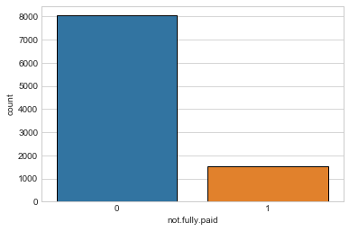

```python
sns.countplot(x='not.fully.paid',data=loanworth)
```

We see that the number of borrowers who have paid their loans to the full is higher.

**Let us create the histogram for FICO score with respect to the Credit Policies**

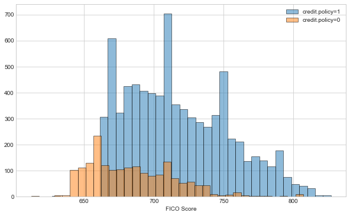

```python
plt.figure(figsize=(10,6))
loanworth[loanworth['credit.policy']==1]['fico'].hist(bins=35,alpha=0.5,label='credit.policy=1')
loanworth[loanworth['credit.policy']==0]['fico'].hist(bins=35,alpha=0.5,label='credit.policy=0')
plt.xlabel('FICO Score')
plt.legend()
```

Borrowers having higher FICO scores meets the credit underwriting criteria of LendingClub.com

**Creating the histogram of FICO score with respect to the not.fully.paid column.**

[figure not shown]

```python
plt.figure(figsize=(10,6))
loanworth[loanworth['not.fully.paid']==0]['fico'].hist(bins=35,alpha=0.5,label='not.fully.paid=1')
loanworth[loanworth['not.fully.paid']==1]['fico'].hist(bins=35,alpha=0.5,label='not.fully.paid=0')
plt.xlabel('FICO Score')
plt.legend()
```

**Analyzing the trend between FICO score and interest rate now**

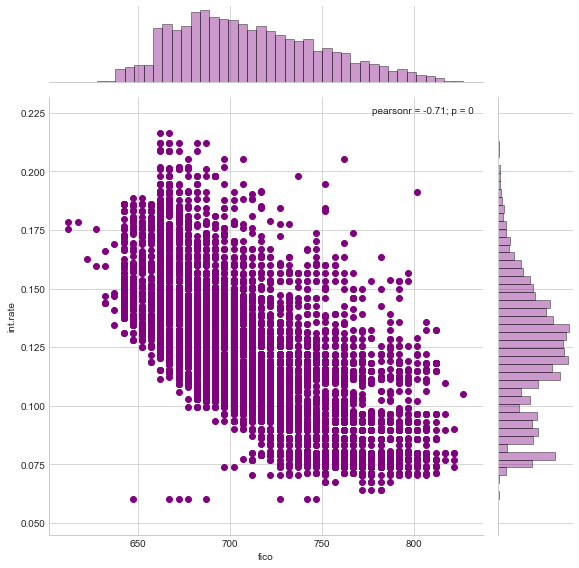

```python
sns.jointplot(x='fico',y='int.rate',data=loanworth,color='purple',size=8)
```

We see that lower FICO scores have higher interest rates.

**Now analyzing the trend between not.fully.paid and credit.policy.**

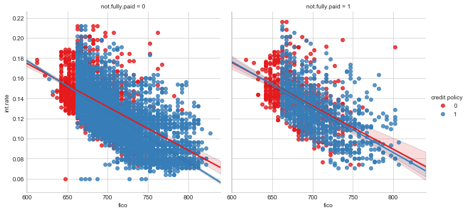

```python
sns.lmplot(x='fico',y='int.rate',data=loanworth,col='not.fully.paid',hue='credit.policy',palette='Set1')
```

The trend of FICO score and interest rate is similar as we expect for those that fully paid balances versus those that did not.

# Setting up the Data

```python
loanworth.info()
```

```
<class 'pandas.core.frame.DataFrame'>
RangeIndex: 9578 entries, 0 to 9577
Data columns (total 14 columns):
credit.policy        9578 non-null int64
purpose              9578 non-null object
int.rate             9578 non-null float64
installment          9578 non-null float64
log.annual.inc       9578 non-null float64
dti                  9578 non-null float64
fico                 9578 non-null int64
days.with.cr.line    9578 non-null float64
revol.bal            9578 non-null int64
revol.util           9578 non-null float64
inq.last.6mths       9578 non-null int64
delinq.2yrs          9578 non-null int64
pub.rec              9578 non-null int64
not.fully.paid       9578 non-null int64
dtypes: float64(6), int64(7), object(1)
memory usage: 1.0+ MB
```

## Transforming Categorical Variables

Here, PURPOSE column is a categorical variable. Therefore we need to transform them using dummy variables so sklearn will be able to understand them. We will do it using pd.get_dummies.

```python
cat_feats = ['purpose']
```

Converting categorical variable into dummy variable:

```python
final_data = pd.get_dummies(loanworth,columns=cat_feats,drop_first=True)
```

```python
final_data.head()
```

|  | credit.policy | int.rate | installment | log.annual.inc | dti | fico | days.with.cr.line | revol.bal | revol.util | inq.last.6mths | delinq.2yrs | pub.rec | not.fully.paid | purpose_credit_card | purpose_debt_consolidation | purpose_educational | purpose_home_improvement | purpose_major_purchase | purpose_small_business |
| --- | --- | --- | --- | --- | --- | --- | --- | --- | --- | --- | --- | --- | --- | --- | --- | --- | --- | --- | --- |
| 0 | 1 | 0.1189 | 829.10 | 11.350407 | 19.48 | 737 | 5639.958333 | 28854 | 52.1 | 0 | 0 | 0 | 0 | 0 | 1 | 0 | 0 | 0 | 0 |
| 1 | 1 | 0.1071 | 228.22 | 11.082143 | 14.29 | 707 | 2760.000000 | 33623 | 76.7 | 0 | 0 | 0 | 0 | 1 | 0 | 0 | 0 | 0 | 0 |
| 2 | 1 | 0.1357 | 366.86 | 10.373491 | 11.63 | 682 | 4710.000000 | 3511 | 25.6 | 1 | 0 | 0 | 0 | 0 | 1 | 0 | 0 | 0 | 0 |
| 3 | 1 | 0.1008 | 162.34 | 11.350407 | 8.10 | 712 | 2699.958333 | 33667 | 73.2 | 1 | 0 | 0 | 0 | 0 | 1 | 0 | 0 | 0 | 0 |
| 4 | 1 | 0.1426 | 102.92 | 11.299732 | 14.97 | 667 | 4066.000000 | 4740 | 39.5 | 0 | 1 | 0 | 0 | 1 | 0 | 0 | 0 | 0 | 0 |

## Train-Test Split of Dataset

Split our data into a training set and a test set! We will do a 70/30 split and use a random state for reproducibility.

```python
from sklearn.model_selection import train_test_split
```

```python
final_data.columns
```

```
Index(['credit.policy', 'int.rate', 'installment', 'log.annual.inc', 'dti',
       'fico', 'days.with.cr.line', 'revol.bal', 'revol.util',
       'inq.last.6mths', 'delinq.2yrs', 'pub.rec', 'not.fully.paid',
       'purpose_credit_card', 'purpose_debt_consolidation',
       'purpose_educational', 'purpose_home_improvement',
       'purpose_major_purchase', 'purpose_small_business'],
      dtype='object')
```

```python
X = final_data.drop('not.fully.paid',axis=1)
y = final_data['not.fully.paid']
```

```python
X_train, X_test, y_train, y_test = train_test_split(X, y, test_size=0.3, random_state=101)
```

## Training the data using Logistic Regression Model

```python
from sklearn.linear_model import LogisticRegression
```

```python
log_model = LogisticRegression()
```

```python
log_model.fit(X_train,y_train)
```

```
LogisticRegression(C=1.0, class_weight=None, dual=False, fit_intercept=True,
          intercept_scaling=1, max_iter=100, multi_class='ovr', n_jobs=1,
          penalty='l2', random_state=None, solver='liblinear', tol=0.0001,
          verbose=0, warm_start=False)
```

```python
log_predictions = log_model.predict(X_test)
```

## Training the data using Decision Tree Model

```python
from sklearn.tree import DecisionTreeClassifier
```

```python
dtree = DecisionTreeClassifier(random_state=101)
```

```python
dtree.fit(X_train,y_train)
```

```
DecisionTreeClassifier(class_weight=None, criterion='gini', max_depth=None,
            max_features=None, max_leaf_nodes=None,
            min_impurity_decrease=0.0, min_impurity_split=None,
            min_samples_leaf=1, min_samples_split=2,
            min_weight_fraction_leaf=0.0, presort=False, random_state=101,
            splitter='best')
```

```python
dtree_predictions = dtree.predict(X_test)
```

## Training the data using Random Forest Model

```python
from sklearn.ensemble import RandomForestClassifier
```

```python
rfc = RandomForestClassifier(n_estimators=1000,random_state=101)
```

```python
rfc.fit(X_train,y_train)
```

```
RandomForestClassifier(bootstrap=True, class_weight=None, criterion='gini',
            max_depth=None, max_features='auto', max_leaf_nodes=None,
            min_impurity_decrease=0.0, min_impurity_split=None,
            min_samples_leaf=1, min_samples_split=2,
            min_weight_fraction_leaf=0.0, n_estimators=1000, n_jobs=1,
            oob_score=False, random_state=101, verbose=0, warm_start=False)
```

```python
rfc_predictions = rfc.predict(X_test)
```

## Implying Confusion Matrix on all models to test the accuracy of models

```python
from sklearn.metrics import classification_report, confusion_matrix
```

**Logistic Regression Model:**

```python
print('Confusion Matrix:')
print(confusion_matrix(y_test,log_predictions))
print('\n')
print('Classification Report:')
print(classification_report(y_test,log_predictions))
```

```
Confusion Matrix:
[[2425    6]
 [ 434    9]]


Classification Report:
             precision    recall  f1-score   support

          0       0.85      1.00      0.92      2431
          1       0.60      0.02      0.04       443

avg / total       0.81      0.85      0.78      2874
```

The logistic regression predicted very well for the fully paid class, but terribly on the not fully paid class.

**Decision Tree Model:**

```python
print('Confusion Matrix:')
print(confusion_matrix(y_test,dtree_predictions))
print('\n')
print('Classification Report:')
print(classification_report(y_test,dtree_predictions))
```

```
Confusion Matrix:
[[1976  455]
 [ 336  107]]


Classification Report:
             precision    recall  f1-score   support

          0       0.85      0.81      0.83      2431
          1       0.19      0.24      0.21       443

avg / total       0.75      0.72      0.74      2874
```

The decision tree predicted decently on the fully paid class, but bad on the not fully paid class. However, it's an improvement from the logistic regression.

**Random Forest Model:**

```python
print('Confusion Matrix:')
print(confusion_matrix(y_test,rfc_predictions))
print('\n')
print('Classification Report:')
print(classification_report(y_test,rfc_predictions))
```

```
Confusion Matrix:
[[2420   11]
 [ 431   12]]


Classification Report:
             precision    recall  f1-score   support

          0       0.85      1.00      0.92      2431
          1       0.52      0.03      0.05       443

avg / total       0.80      0.85      0.78      2874
```

The random forest model is very similar to the logistic regression. Better performance on the fully paid class, but terrible on the not fully paid class.

We now have the accuracy analyis for all the models on both the cases i.e. Paid Fully and Not Paid Fully.

## Conclusion:

When we check the average/total of the classification report, we see that the Random Forest and Logistic Regression models perform better than Decision Tree model on all the criterias. But when analyzed indivisually, the performance of logistic regression and random forest models for the not fully paid class is bad in comparison to decision tree model. The decision tree is the better model for predicting accuracy in both classes. So, if the investors want to decide who they should lend loans to in future, they should consider both the classes simultaneously to make a fair decision and not loose out any potential customer neither give credit a bad borrower.